# Data processing with Apache Spark

## Task 5 Bonus: List of articles requested by users:

In this task we need to get a list of articles requested by each user as the following:

- Please find the attached two files with this session (weblogs, kblist).
- The structure of the input files and the output is presented in the figure below. The weblogs file records the IP address-UserID then the Http command, e.g. GET, issued against a resource. We are interested in knowledge base documents. They are named by KBDOC-XXXXX.html. The kblist file contains entries in the form KBDOC-XXXXX title.
- The ouput should consist of pairs where the first element is the UserID and the second element is the list of knowledge base document titles requested by the user.

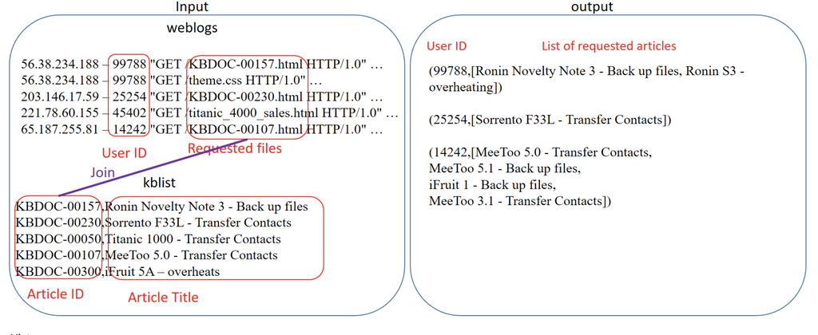

```python
from IPython.display import Image
Image(filename='BonusTask.png')
```

Hints:

- Map separate datasets into key‐value Pair RDDs
- Map web log requests to (docid,userid)
- Map KB Doc index to (docid,title)
- Join by key: docid
- Map joined data into the desired format: (userid,title)

# Expected delieverables

- Nmae each .py file with the task_taskNumber
- put all .py files and the notebook in a folder and compress it then submit it on canvas